# final (1)

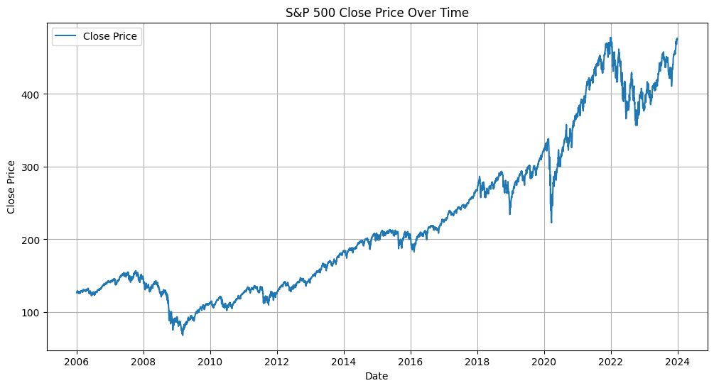

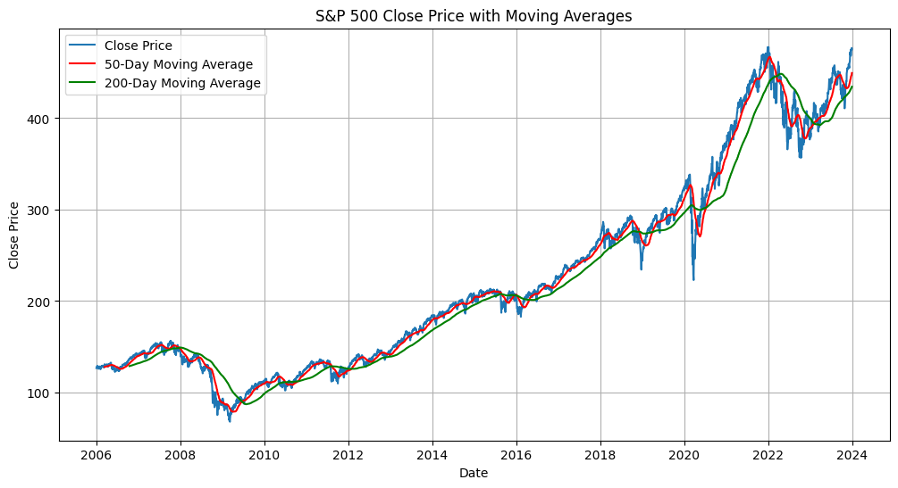

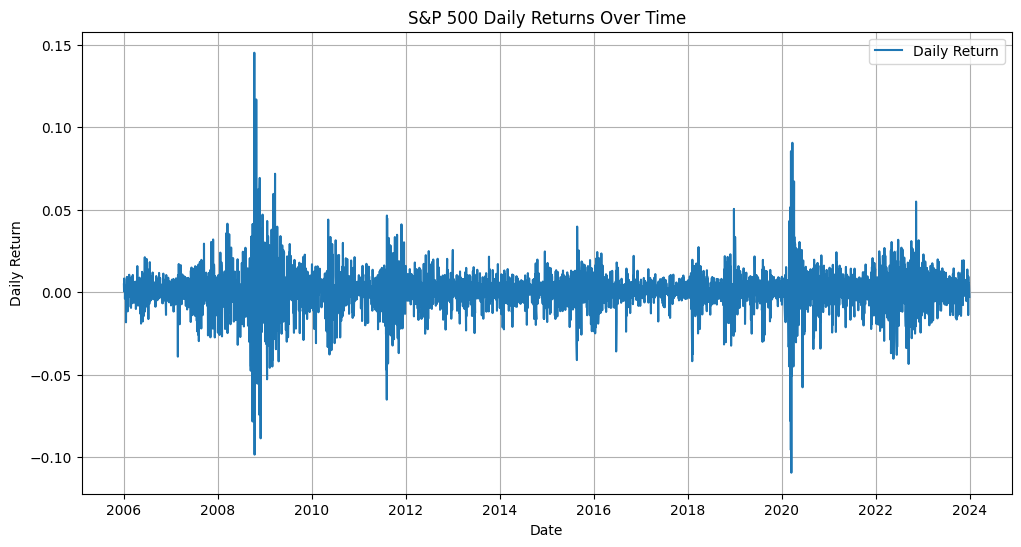

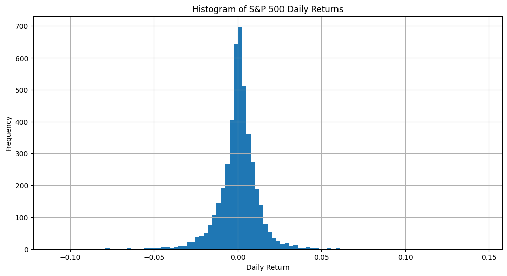

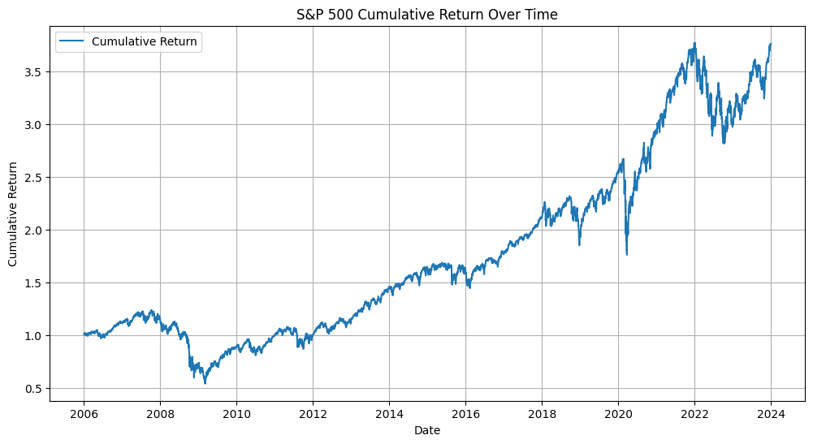

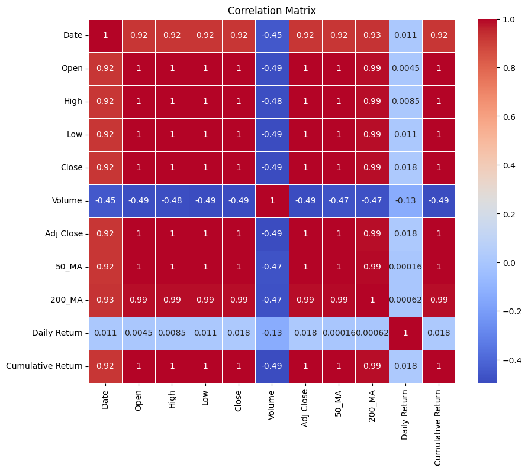

```python
# Plotting the Close Price over time
plt.figure(figsize=(12, 6))
plt.plot(sp500_data['Date'], sp500_data['Close'], label='Close Price')
plt.title('S&P 500 Close Price Over Time')
plt.xlabel('Date')
plt.ylabel('Close Price')
plt.legend()
plt.grid(True)
plt.show()

# Calculate Moving Averages
sp500_data['50_MA'] = sp500_data['Close'].rolling(window=50).mean()
sp500_data['200_MA'] = sp500_data['Close'].rolling(window=200).mean()

plt.figure(figsize=(12, 6))
plt.plot(sp500_data['Date'], sp500_data['Close'], label='Close Price')
plt.plot(sp500_data['Date'], sp500_data['50_MA'], label='50-Day Moving Average', color='red')
plt.plot(sp500_data['Date'], sp500_data['200_MA'], label='200-Day Moving Average', color='green')
plt.title('S&P 500 Close Price with Moving Averages')
plt.xlabel('Date')
plt.ylabel('Close Price')
plt.legend()
plt.grid(True)
plt.show()

# Daily returns
sp500_data['Daily Return'] = sp500_data['Close'].pct_change()

plt.figure(figsize=(12, 6))
plt.plot(sp500_data['Date'], sp500_data['Daily Return'], label='Daily Return')
plt.title('S&P 500 Daily Returns Over Time')
plt.xlabel('Date')
plt.ylabel('Daily Return')
plt.legend()
plt.grid(True)
plt.show()

# Histogram of daily returns
plt.figure(figsize=(12, 6))
sp500_data['Daily Return'].hist(bins=100)
plt.title('Histogram of S&P 500 Daily Returns')
plt.xlabel('Daily Return')
plt.ylabel('Frequency')
plt.grid(True)
plt.show()

# Cumulative return
sp500_data['Cumulative Return'] = (1 + sp500_data['Daily Return']).cumprod()

plt.figure(figsize=(12, 6))
plt.plot(sp500_data['Date'], sp500_data['Cumulative Return'], label='Cumulative Return')
plt.title('S&P 500 Cumulative Return Over Time')
plt.xlabel('Date')
plt.ylabel('Cumulative Return')
plt.legend()
plt.grid(True)
plt.show()

# Correlation matrix
plt.figure(figsize=(10, 8))
correlation_matrix = sp500_data.corr()
sns.heatmap(correlation_matrix, annot=True, cmap='coolwarm', linewidths=0.5)
plt.title('Correlation Matrix')
plt.show()
```

# S&P 500 Analysis

## 1. S&P 500 Close Price Over Time

**Description:** This plot shows the daily closing prices of the S&P 500 index from 2006 to 2024.

**Key Insights:**

- **Trend Identification:** The plot displays a general upward trend in the S&P 500 index over the period, indicating overall market growth.
- **Major Events:** Significant drops can be observed during the 2008 financial crisis and the COVID-19 pandemic in 2020, reflecting their impact on the stock market.
- **Volatility:** The plot also highlights periods of higher volatility, where price fluctuations are more pronounced.

## 2. S&P 500 Close Price with Moving Averages

**Description:** This plot shows the daily closing prices of the S&P 500 index along with the 50-day and 200-day moving averages.

**Key Insights:**

- **Short-term vs. Long-term Trends:** The 50-day moving average (red line) provides a view of short-term trends, while the 200-day moving average (green line) shows long-term trends.
- **Trend Reversal:** When the 50-day moving average crosses above the 200-day moving average, it often signals a bullish trend (buy signal). Conversely, crossing below can indicate a bearish trend (sell signal).
- **Smoothing Effect:** The moving averages smooth out short-term fluctuations, making it easier to identify underlying trends.

## 3. S&P 500 Daily Returns Over Time

**Description:** This plot shows the daily returns of the S&P 500 index over time, calculated as the percentage change in closing prices from one day to the next.

**Key Insights:**

- **Volatility:** The plot highlights periods of high volatility, such as during the 2008 financial crisis and the COVID-19 pandemic, where daily returns show significant fluctuations.
- **Mean Reversion:** Over time, the daily returns fluctuate around a mean value, suggesting that extreme movements are often followed by corrections.
- **Outliers:** Large spikes in the plot indicate days with unusually high positive or negative returns, often corresponding to major market events or news.

## 4. Histogram of S&P 500 Daily Returns

**Description:** This histogram shows the distribution of daily returns for the S&P 500 index.

**Key Insights:**

- **Normal Distribution:** The histogram appears to follow a roughly normal distribution centered around a mean close to zero, indicating that small daily changes are more common than large ones.
- **Skewness and Kurtosis:** The presence of fat tails suggests that extreme returns (both positive and negative) occur more frequently than in a normal distribution, indicating higher risk.
- **Frequency of Returns:** The majority of daily returns are clustered around the mean, with fewer occurrences of large positive or negative returns.

## 5. S&P 500 Cumulative Return Over Time

**Description:** This plot shows the cumulative return of the S&P 500 index over time, assuming an initial investment of $1.

**Key Insights:**

- **Growth Over Time:** The plot indicates overall growth in the S&P 500 index over the period, showing how an investment would have increased in value.
- **Impact of Crises:** The cumulative return plot highlights the impact of major financial crises, such as the 2008 financial crisis and the COVID-19 pandemic, where the cumulative returns drop significantly.
- **Rebound:** The market's ability to recover after significant drops is also evident, as seen in the upward trend following the 2008 financial crisis and the initial COVID-19 impact.

## 6. Correlation Matrix

**Key Insights:**

[figure not shown]

# Statistical Analysis of S&P 500 Data

In this section, we conduct various statistical tests to analyze the S&P 500 data. We use T Test, Mann-Whitney U Test, and ANOVA to gain insights into different periods, including pre-crisis, crisis, post-crisis, pre-COVID, and COVID periods.

## T Test

- Pre-crisis vs. Crisis
- Post-crisis vs. Crisis
- Pre-COVID vs. COVID

## Mann-Whitney U Test

- Pre-crisis vs. Crisis
- Post-crisis vs. Crisis
- Pre-COVID vs. COVID

## ANOVA

ANOVA (Analysis of Variance) is used to compare the means of three or more groups. It helps in determining if there are any statistically significant differences between the means of different groups.

# Presenting Conclusions and Visualizations

## Conclusion 1: Correlation Analysis

- High positive correlations between the High, Low, Open, Close, and Adjusted Close prices indicate that these prices move together, as expected.

## Conclusion 2: Outlier Detection

- From the daily returns plot and the histogram of daily returns, we detect outliers representing extreme market movements. These outliers are often associated with major financial events, such as the 2008 financial crisis and the COVID-19 pandemic.

## Conclusion 3: Hypothesis Testing

*Code implementation*

```
T-test results (Pre-crisis vs. Crisis):
T-statistic: 48.551537494692404, P-value: 1.3188786456946913e-239

T-test results (Post-crisis vs. Crisis):
T-statistic: 20.566102365743088, P-value: 7.935318848098038e-88

T-test results (Pre-COVID vs. COVID):
T-statistic: -30.557016371513285, P-value: 1.2667102798661774e-183

Mann-Whitney U Test results (Pre-crisis vs. Crisis):
U-statistic: 82669.0, P-value: 8.338010075994726e-69

Mann-Whitney U Test results (Post-crisis vs. Crisis):
U-statistic: 327032.0, P-value: 2.3892312212826155e-65

Mann-Whitney U Test results (Pre-COVID vs. COVID):
U-statistic: 24320.0, P-value: 2.3946318252819254e-139

ANOVA Test results:
F-statistic: 448.75165340986644, P-value: 0.0
```

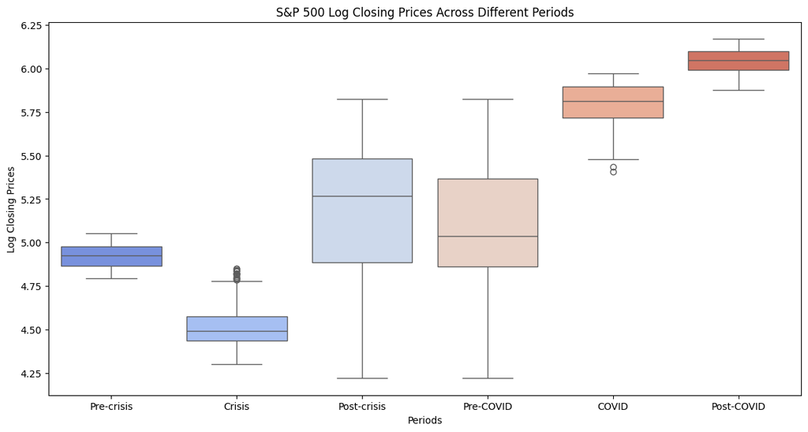

```python
from scipy.stats import ttest_ind, mannwhitneyu, f_oneway

# Define periods
crisis_start = '2008-09-01'
crisis_end = '2009-03-01'
pre_crisis_end = '2008-08-31'
post_crisis_start = '2009-03-02'

covid_start = '2020-03-01'
covid_end = '2021-03-01'
pre_covid_end = '2020-02-29'

# Filter data for the periods
crisis_data = sp500_data[(sp500_data['Date'] >= crisis_start) & (sp500_data['Date'] <= crisis_end)]
pre_crisis_data = sp500_data[sp500_data['Date'] <= pre_crisis_end]
post_crisis_data = sp500_data[(sp500_data['Date'] >= post_crisis_start) & (sp500_data['Date'] < covid_start)]
covid_data = sp500_data[(sp500_data['Date'] >= covid_start) & (sp500_data['Date'] <= covid_end)]
post_covid_data = sp500_data[sp500_data['Date'] > covid_end]
pre_covid_data = sp500_data[sp500_data['Date'] <= pre_covid_end]

# Extract the closing prices
crisis_prices = crisis_data['Close']
pre_crisis_prices = pre_crisis_data['Close']
post_crisis_prices = post_crisis_data['Close']
covid_prices = covid_data['Close']
post_covid_prices = post_covid_data['Close']
pre_covid_prices = pre_covid_data['Close']

# Check for non-empty periods
periods = {
    "Pre-crisis": pre_crisis_prices,
    "Crisis": crisis_prices,
    "Post-crisis": post_crisis_prices,
    "Pre-COVID": pre_covid_prices,
    "COVID": covid_prices,
    "Post-COVID": post_covid_prices
}

for period, prices in periods.items():
    if prices.empty:
        print(f"Warning: No data for {period} period.")
        periods[period] = np.nan

# Apply log transformation to the closing prices
log_crisis_prices = np.log(periods["Crisis"])
log_pre_crisis_prices = np.log(periods["Pre-crisis"])
log_post_crisis_prices = np.log(periods["Post-crisis"])
log_covid_prices = np.log(periods["COVID"])
log_post_covid_prices = np.nan if np.isnan(periods["Post-COVID"]).all() else np.log(periods["Post-COVID"])
log_pre_covid_prices = np.log(periods["Pre-COVID"])

# Perform T-tests
pre_vs_crisis_ttest = ttest_ind(log_pre_crisis_prices, log_crisis_prices)
post_vs_crisis_ttest = ttest_ind(log_post_crisis_prices, log_crisis_prices)
pre_covid_vs_covid_ttest = ttest_ind(log_pre_covid_prices, log_covid_prices)

print("T-test results (Pre-crisis vs. Crisis):")
print(f"T-statistic: {pre_vs_crisis_ttest.statistic}, P-value: {pre_vs_crisis_ttest.pvalue}")

print("\nT-test results (Post-crisis vs. Crisis):")
print(f"T-statistic: {post_vs_crisis_ttest.statistic}, P-value: {post_vs_crisis_ttest.pvalue}")

print("\nT-test results (Pre-COVID vs. COVID):")
print(f"T-statistic: {pre_covid_vs_covid_ttest.statistic}, P-value: {pre_covid_vs_covid_ttest.pvalue}")

# Perform Mann-Whitney U Test
pre_vs_crisis_mannwhitney = mannwhitneyu(log_pre_crisis_prices, log_crisis_prices)
post_vs_crisis_mannwhitney = mannwhitneyu(log_post_crisis_prices, log_crisis_prices)
pre_covid_vs_covid_mannwhitney = mannwhitneyu(log_pre_covid_prices, log_covid_prices)

print("\nMann-Whitney U Test results (Pre-crisis vs. Crisis):")
print(f"U-statistic: {pre_vs_crisis_mannwhitney.statistic}, P-value: {pre_vs_crisis_mannwhitney.pvalue}")

print("\nMann-Whitney U Test results (Post-crisis vs. Crisis):")
print(f"U-statistic: {post_vs_crisis_mannwhitney.statistic}, P-value: {post_vs_crisis_mannwhitney.pvalue}")

print("\nMann-Whitney U Test results (Pre-COVID vs. COVID):")
print(f"U-statistic: {pre_covid_vs_covid_mannwhitney.statistic}, P-value: {pre_covid_vs_covid_mannwhitney.pvalue}")

# Perform ANOVA
anova_test = f_oneway(log_pre_crisis_prices, log_crisis_prices, log_post_crisis_prices, log_pre_covid_prices, log_covid_prices)
print("\nANOVA Test results:")
print(f"F-statistic: {anova_test.statistic}, P-value: {anova_test.pvalue}")

# Combine data into a single DataFrame for plotting
log_data_dict = {
    'Pre-crisis': log_pre_crisis_prices,
    'Crisis': log_crisis_prices,
    'Post-crisis': log_post_crisis_prices,
    'Pre-COVID': log_pre_covid_prices,
    'COVID': log_covid_prices,
}

# Add Post-COVID data if available
if not np.isnan(log_post_covid_prices).any():
    log_data_dict['Post-COVID'] = log_post_covid_prices

combined_log_data = pd.DataFrame(log_data_dict)

# Melt the DataFrame for easier plotting
combined_log_data_melted = combined_log_data.melt(var_name='Period', value_name='Log Closing Prices')

# Combined boxplot with log-transformed data
plt.figure(figsize=(14, 7))
sns.boxplot(x='Period', y='Log Closing Prices', hue='Period', data=combined_log_data_melted, palette="coolwarm", dodge=False, legend=False)
plt.title('S&P 500 Log Closing Prices Across Different Periods')
plt.ylabel('Log Closing Prices')
plt.xlabel('Periods')
plt.show()
```

*Interpretation:*

*Conclusion 3: Hypothesis Testing*

[figure not shown]

# Predictive Modeling

## Model Selection

In the context of stock market prediction, several models can be considered, ranging from traditional statistical models to advanced machine learning models. common choices:

1. **Linear Regression:**  
   A basic model to predict future stock prices based on past values.
2. **ARIMA (AutoRegressive Integrated Moving Average):**  
   A statistical model for time series forecasting.
3. **LSTM (Long Short-Term Memory):**  
   A type of recurrent neural network (RNN) well-suited for time series data.
4. **Random Forest:**  
   An ensemble learning method for regression that can handle non-linear relationships.

For this analysis, we will implement and evaluate two models:

1. **ARIMA:**  
   For its effectiveness in time series forecasting.
2. **LSTM:**  
   For capturing more complex patterns in the data.

## Model Implementation

### 1. ARIMA Model

```
ARIMA(0, 0, 0) MSE=38169.044111340656
ARIMA(0, 0, 1) MSE=38164.82108563577
ARIMA(0, 0, 2) MSE=38157.30113705548
ARIMA(0, 0, 3) MSE=38163.642665773834
ARIMA(0, 0, 4) MSE=38163.11514733161
ARIMA(0, 0, 5) MSE=38162.00688758919
ARIMA(0, 1, 0) MSE=18426.477943973514
ARIMA(0, 1, 1) MSE=18406.4194023882
ARIMA(0, 1, 2) MSE=18400.995643953374
ARIMA(0, 1, 3) MSE=18400.933389851012
ARIMA(0, 1, 4) MSE=18401.210334940955
ARIMA(0, 1, 5) MSE=18411.103202412498
ARIMA(1, 0, 0) MSE=21013.739902588546
ARIMA(1, 0, 1) MSE=29036.909087285934
ARIMA(1, 0, 2) MSE=28182.679253062717
ARIMA(1, 0, 3) MSE=28397.184716939242
ARIMA(1, 0, 4) MSE=28220.797185215775
ARIMA(1, 0, 5) MSE=27338.845128077617
ARIMA(1, 1, 0) MSE=18409.31894096798
ARIMA(1, 1, 1) MSE=18405.785590315434
ARIMA(1, 1, 2) MSE=18400.901311486552
ARIMA(1, 1, 3) MSE=18400.941904538064
ARIMA(1, 1, 4) MSE=18422.323679744626
ARIMA(1, 1, 5) MSE=18411.81975108499
ARIMA(2, 0, 0) MSE=29327.787835252257
ARIMA(2, 0, 1) MSE=30650.523064954392
ARIMA(2, 0, 2) MSE=28937.05479664881
ARIMA(2, 0, 3) MSE=27968.927073032384
ARIMA(2, 0, 4) MSE=28605.054128678068
ARIMA(2, 0, 5) MSE=27879.81715270487
ARIMA(2, 1, 0) MSE=18400.696497393288
ARIMA(2, 1, 1) MSE=18400.863996816694
ARIMA(2, 1, 2) MSE=18404.10843084873
ARIMA(2, 1, 3) MSE=18418.12755866306
ARIMA(2, 1, 4) MSE=18359.101573298325
ARIMA(2, 1, 5) MSE=18422.023072897788
ARIMA(3, 0, 0) MSE=28306.442950858564
ARIMA(3, 0, 1) MSE=29457.615421069026
ARIMA(3, 0, 2) MSE=30948.386486477106
ARIMA(3, 0, 3) MSE=28402.11699090711
```

[output cut: 18 more lines]

```
ARIMA(4, 1, 4) MSE=18451.854385514685
ARIMA(4, 1, 5) MSE=18352.298578090235
ARIMA(5, 0, 0) MSE=28476.413236803175
ARIMA(5, 0, 1) MSE=28676.08649503112
ARIMA(5, 0, 2) MSE=27597.117217949948
ARIMA(5, 0, 3) MSE=23919.930625213405
ARIMA(5, 0, 4) MSE=31906.264780628084
ARIMA(5, 0, 5) MSE=19235.21031707397
ARIMA(5, 1, 0) MSE=18403.155761483224
ARIMA(5, 1, 1) MSE=18408.801067212342
ARIMA(5, 1, 2) MSE=18419.416435783547
ARIMA(5, 1, 3) MSE=18367.215358818026
ARIMA(5, 1, 4) MSE=18351.953953650005
ARIMA(5, 1, 5) MSE=18296.96341560467
Best ARIMA order: (5, 1, 5) with MSE: 18296.96341560467
```

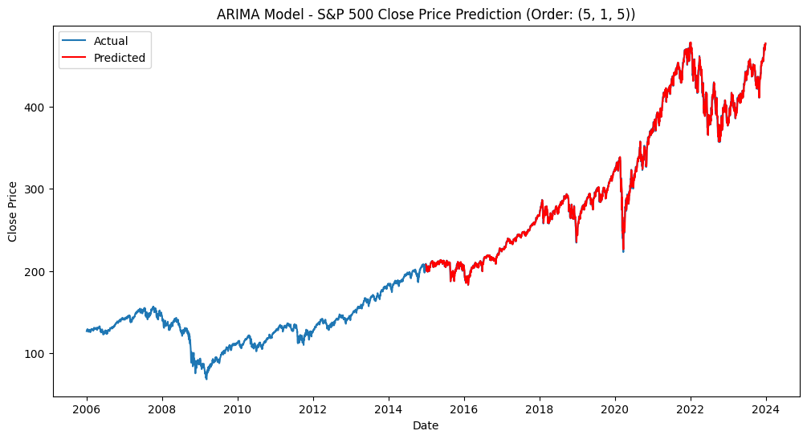

```
ARIMA Model MSE: 12.702552082931916
ARIMA Model MAPE: 0.0074706149848284015
```

```python
import matplotlib.pyplot as plt
from statsmodels.tsa.arima.model import ARIMA
from sklearn.metrics import mean_squared_error, mean_absolute_percentage_error


sp500_data = pd.read_csv('new_sp500_data.csv')

# Convert the 'Date' column to datetime format and set it as the index
sp500_data['Date'] = pd.to_datetime(sp500_data['Date'], errors='coerce')
sp500_data = sp500_data.dropna(subset=['Date'])
sp500_data.set_index('Date', inplace=True)

# Convert 'Close' column to numeric and drop non-numeric rows
sp500_data['Close'] = pd.to_numeric(sp500_data['Close'], errors='coerce')
sp500_data = sp500_data.dropna(subset=['Close'])

# Prepare the data
close_prices = sp500_data['Close']

# Split the data into training and testing sets (50% training, 50% testing)
train_size = int(len(close_prices) * 0.5)
train, test = close_prices[:train_size], close_prices[train_size:]

#  a function to fit and predict using ARIMA
def fit_predict_arima(train, test, order):
    model = ARIMA(train, order=order)
    model_fit = model.fit()

    # Forecast the test set
    predictions = model_fit.forecast(steps=len(test))
    return predictions, model_fit

# Define the ARIMA orders to evaluate
p_values = range(0, 6)
d_values = range(0, 2)
q_values = range(0, 6)

best_score, best_order = float('inf'), None

# Evaluat different ARIMA models
for p in p_values:
    for d in d_values:
        for q in q_values:
            order = (p, d, q)
            try:
                predictions, model_fit = fit_predict_arima(train, test, order)
                mse = mean_squared_error(test, predictions)
                print(f'ARIMA{order} MSE={mse}')
                if mse < best_score:
                    best_score, best_order = mse, order
            except Exception as e:
                continue

print(f'Best ARIMA order: {best_order} with MSE: {best_score}')

# Fit the best ARIMA model
best_model = ARIMA(close_prices, order=best_order)
best_model_fit = best_model.fit()

# Make predictions
predictions = best_model_fit.predict(start=len(train), end=len(close_prices)-1, typ='levels')

# Plot the results
plt.figure(figsize=(12, 6))
plt.plot(close_prices, label='Actual')
plt.plot(predictions, label='Predicted', color='red')
plt.title(f'ARIMA Model - S&P 500 Close Price Prediction (Order: {best_order})')
plt.xlabel('Date')
plt.ylabel('Close Price')
plt.legend()
plt.show()

# Calculate MSE and MAPE
mse = mean_squared_error(test, predictions)
mape = mean_absolute_percentage_error(test, predictions)
print(f'ARIMA Model MSE: {mse}')
print(f'ARIMA Model MAPE: {mape}')
```

# 2.LSTM Model

```
3612/3612 - 2s - 479us/step - loss: 3.6619e-04
3612/3612 - 1s - 315us/step - loss: 1.1715e-04
3612/3612 - 2s - 448us/step - loss: 1.0111e-04
3612/3612 - 2s - 474us/step - loss: 8.6207e-05
3612/3612 - 2s - 438us/step - loss: 7.9824e-05
3612/3612 - 2s - 463us/step - loss: 7.4220e-05
3612/3612 - 2s - 525us/step - loss: 7.0156e-05
3612/3612 - 2s - 479us/step - loss: 6.5059e-05
3612/3612 - 1s - 376us/step - loss: 6.6032e-05
3612/3612 - 2s - 428us/step - loss: 6.7130e-05
3612/3612 - 2s - 467us/step - loss: 6.5001e-05
3612/3612 - 2s - 421us/step - loss: 5.9159e-05
3612/3612 - 1s - 403us/step - loss: 5.5586e-05
3612/3612 - 2s - 460us/step - loss: 5.7583e-05
3612/3612 - 1s - 409us/step - loss: 5.4529e-05
3612/3612 - 1s - 414us/step - loss: 5.5607e-05
3612/3612 - 2s - 427us/step - loss: 5.4437e-05
3612/3612 - 1s - 411us/step - loss: 5.1945e-05
3612/3612 - 1s - 377us/step - loss: 5.4960e-05
3612/3612 - 1s - 379us/step - loss: 5.1289e-05
113/113 ━━━━━━━━━━━━━━━━━━━━ 0s 867us/step
28/28 ━━━━━━━━━━━━━━━━━━━━ 0s 351us/step
LSTM Model Test Score: 15.887553102496192 RMSE
```

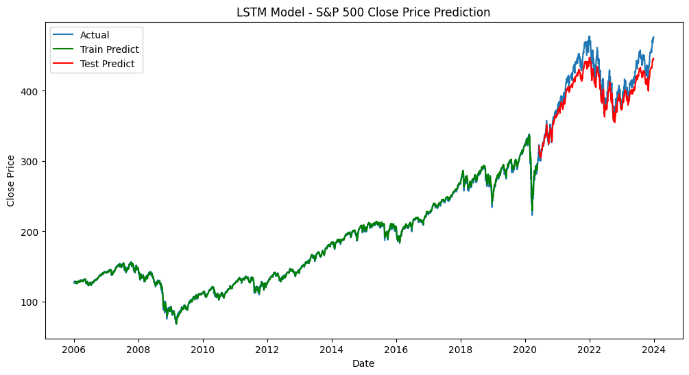

```python
from keras.models import Sequential
from keras.layers import Dense, LSTM
from sklearn.preprocessing import MinMaxScaler

# Prepare the data for LSTM
scaler = MinMaxScaler(feature_range=(0, 1))
scaled_data = scaler.fit_transform(close_prices.values.reshape(-1, 1))

# Split the data into training and testing sets
train_size = int(len(scaled_data) * 0.8)
train, test = scaled_data[:train_size], scaled_data[train_size:]

# Create the dataset with look_back
def create_dataset(dataset, look_back=1):
    X, Y = [], []
    for i in range(len(dataset)-look_back-1):
        a = dataset[i:(i+look_back), 0]
        X.append(a)
        Y.append(dataset[i + look_back, 0])
    return np.array(X), np.array(Y)

look_back = 10
X_train, Y_train = create_dataset(train, look_back)
X_test, Y_test = create_dataset(test, look_back)

# Reshape input to be [samples, time steps, features]
X_train = np.reshape(X_train, (X_train.shape[0], 1, X_train.shape[1]))
X_test = np.reshape(X_test, (X_test.shape[0], 1, X_test.shape[1]))

# Create and fit the LSTM network
model = Sequential()
model.add(LSTM(50, input_shape=(1, look_back)))
model.add(Dense(1))
model.compile(loss='mean_squared_error', optimizer='adam')
model.fit(X_train, Y_train, epochs=20, batch_size=1, verbose=2)

# Make predictions
train_predict = model.predict(X_train)
test_predict = model.predict(X_test)

# Inve transform predictions
train_predict = scaler.inverse_transform(train_predict)
Y_train = scaler.inverse_transform([Y_train])
test_predict = scaler.inverse_transform(test_predict)
Y_test = scaler.inverse_transform([Y_test])

# Evalu the model
test_score = np.sqrt(mean_squared_error(Y_test[0], test_predict[:, 0]))
print(f'LSTM Model Test Score: {test_score} RMSE')

# Plot the results
plt.figure(figsize=(12, 6))
plt.plot(close_prices.index, close_prices, label='Actual')
plt.plot(close_prices.index[look_back:len(train_predict) + look_back], train_predict, label='Train Predict', color='green')
plt.plot(close_prices.index[len(train_predict)+(look_back*2)+1:len(close_prices)-1], test_predict, label='Test Predict', color='red')
plt.title('LSTM Model - S&P 500 Close Price Prediction')
plt.xlabel('Date')
plt.ylabel('Close Price')
plt.legend()
plt.show()
```

# ARIMA Model Analysis: S&P 500 Price Prediction

[figure not shown]

## Model Overview

After evaluating multiple parameter combinations, the optimal model was determined to be ARIMA(5,1,5).

## Potential Improvements

1. **Feature Engineering**:
   - Incorporate exogenous variables such as economic indicators, market sentiment, or company fundamentals.
   - Explore the inclusion of technical indicators (e.g., moving averages, relative strength index).
2. **Model Validation**:
   - Implement rolling window validation to assess performance consistency across different time periods.
   - Conduct out-of-sample testing on more recent data to evaluate real-world applicability.

### Conclusion

The ARIMA(5,1,5) model demonstrates promising results in predicting S&P 500 close prices. While it captures overall trends and major market events effectively, there's room for improvement in handling short-term volatility. The suggested enhancements focus on refining the model's accuracy, robustness, and real-world applicability.

# LSTM Model Analysis: S&P 500 Close Price Prediction

## Model Overview

We implemented a Long Short-Term Memory (LSTM) neural network to predict S&P 500 close prices. The model was trained on historical data with a look-back period of 10 days.

[figure not shown]